# EFI Deep Dive

## Prepare the dataset

All our .txt files are in a directory named Account so I can write a function that will loop through each of the files extract the text and the tile of each file and put them all in a table.

Doing it manually would take a ridiculous amount of time but that is what computer are for so let’s see what we can do.

1. Create a new object that contain the path to our directory

```r
text_files_dir <- "Accounts"
```

2. Create an empty data.table that we are going to populate with the info we are going to extract

```r
text_files <- list.files(text_files_dir, pattern = "\\.txt$", full.names = TRUE)#search for .txt

Scotdata <- data.table(title = character(), text = character())# create a table with two column one named title and one text
```

3. Iterate through each text file We do this by using a forloop function

```r
for (file in text_files) {
  # Specify the encoding (e.g., "latin1")
  text <- tolower(iconv(readLines(file, warn = FALSE), from = "latin1", to = "UTF-8", sub = ""))# tolower gets all text low cap
  title <- gsub(".txt$", "", basename(file))# gsub extracts the pattern define so the tile of the files before .txt
  Scotdata <- rbindlist(list(Scotdata, data.table(title = title, text = paste(text, collapse = " "))))# bind them together
}
```

```r
head(Scotdata)
```

```
##                                         title
## 1:  StAS.1.1.1.C.NullCounty.Contents_and_Misc
## 2:             StAS.1.1.1.P.Roxburgh.Jedburgh
## 3: StAS.1.1.10.C.NullCounty.Contents_and_Misc
## 4:            StAS.1.1.10.P.Roxburgh.Jedburgh
## 5:         StAS.1.1.100.P.Linlithgow.Carriden
## 6:            StAS.1.1.101.P.Ayrshire.Coylton
##                                                                                                                                                                                                                                                                                                          …
## 1:                                                                                                                                                                                                                                                                                                       …
## 2:                                                                                                                                                                                                                                                                                                       …
## 3:                                                                                                                                                                                                                                                                                                       …
## 4:       statistical account  sown in the ground immediately surrounding the town of  jedburgh, and some on tiviot fide; but little or none in the south part of the parish.  turnips and potatoes are a gene- ral crop all over this country.  the culture of turnips, in particular, has been much stud…
## 5:                                                                                                                                                                                                                                                                                                       …
## 6:                                                                                                                                                                                                                                                                                                       …
```

```r
write.csv(Scotdata, "text_data.csv", row.names = FALSE)
```

## Clean and format the data

### Fix some formatting issues

Fix the going to the next line issue. i.e. sub “-” with nothing “” There are a lot of formatting errors (next line, next paragraph) that we want to clean up

```r
ScotdataClean <- mutate_if(Scotdata,
                           is.character, #apply the changes only if the data is a "character" type (e.g. text)
                           str_replace_all,
                           pattern = "-[[:space:]]+","") #What I am searching for+ what I am subbing with
```

### Extract More info from the dataset

To do the following steps we are using regex. Short for regular expression, a regex is a string of text that lets you create patterns that help match, locate, and manage text. Think find and replace in Word

1. Extract area and parish from the title
- P=Parish
- C=Miscellanea
- G=General Observations
- A=Appendix
- F=General
- I=Index
- M=Map

I want to be able to subset the dataset by those and I also want to have them both as a code as a description to do so I need to write a if else clause

```r
ScotdataClean$Type<- sub(".*(P|C|G|A|F|M|I)\\.(.*?)\\..*", "\\1", ScotdataClean$title)#This is selecting the P|C|G|A|F|M|I
ScotdataClean$TypeDescriptive<- ifelse(
  ScotdataClean$Type =="P", "Parish",ifelse(
    ScotdataClean$Type =="C","Miscellanea", ifelse(
      ScotdataClean$Type =="G","General Observations", ifelse(
        ScotdataClean$Type =="A", "Appendix", ifelse(
          ScotdataClean$Type =="F","General", ifelse(
            ScotdataClean$Type =="I", "Index","Map"))))))
```

2. I want the first bit of the title as the RecordId of the document

```r
ScotdataClean$RecordID<- sub("^(StAS\\.\\d+\\.\\d+\\.\\d+).*","\\1",  ScotdataClean$title)
```

3. I also want to extract the area that is the bit after p/c/g/a/f/m/i

```r
ScotdataClean$Area<- sub(".*(P|C|G|A|F|M|I)\\.(.*?)\\..*", "\\2", ScotdataClean$title)# //2 cause I want to select the second bit so after the letters
```

4. Extract the Parish. I can do so by extracting the last bit up until the full stop

```r
ScotdataClean$Parish<- sub(".*\\.", "", ScotdataClean$title)
```

### Subset the dataset to only keep the text with information from the parishes

We will now start to look at what is inside but before starting our analysis we want to work only on the parish observations since a lot of the other documents are part of indexes or summaries

```r
Parish<-subset(ScotdataClean, Type =="P")
```

# Explore the dataset created

Create a Quanteda corpus of the ‘text’ column from our data set A corpus class object containing the original texts, document-level variables, document-level metadata, corpus-level metadata, and default settings for subsequent processing of the corpus. For quanteda >= 2.0, this is a specially classed character vector.

```r
CorpusStat<-corpus(Parish$text)
```

## Summarise the content of the corpus

```r
summary(CorpusStat, 5)
```

```
## Corpus consisting of 27065 documents, showing 5 documents:
##
##   Text Types Tokens Sentences
##  text1    94    171         1
##  text2   167    399         1
##  text3   122    201         1
##  text4   123    262         1
##  text5   146    273         1
```

Check how many docs are in the corpus

```r
ndoc(CorpusStat)
```

```
## [1] 27065
```

Check number of characters in the first 10 documents of the corpus

```r
nchar(CorpusStat[1:10])
```

```
##  text1  text2  text3  text4  text5  text6  text7  text8  text9 text10
##    948   1914   1018   1253   1362   1430   2003   1924   1866   1983
```

# Part2: Geographical Data

Since our data are all connected with places in Scotland we can look at topics within our dataset and how popular they are in different areas of Scotland.

To do so we need to work with a geoPackage containing the same information about the areas of Scotland contained in the dataset. GeoPackage is an open, portable, self-describing, compact format for transferring geo-spatial information. In our case it is a vectorial representation of the areas of Scotland in which the accounts are subdivided.

Look at what is inside our dataset

```r
summary(Parish)
```

```
##     title               text               Type           TypeDescriptive
##  Length:27065       Length:27065       Length:27065       Length:27065
##  Class :character   Class :character   Class :character   Class :character
##  Mode  :character   Mode  :character   Mode  :character   Mode  :character
##    RecordID             Area              Parish
##  Length:27065       Length:27065       Length:27065
##  Class :character   Class :character   Class :character
##  Mode  :character   Mode  :character   Mode  :character
```

### Import the Geographical Data

Then we import the first GeoPackage. A GeoPackage is an open, standards-based format designed for the efficient storage, transfer, and exchange of geospatial data. Developed by the Open Geospatial Consortium (OGC), it serves as a container for various types of geospatial information, including vector features, raster maps, and attribute data, all within a single file https://www.geopackage.org/.

st_read Function: * from st package that reads vector spatial data. * dsn = data source name, essentially the file name and the folder path

```r
ParishesGeo <- st_read(dsn = "Spatial/Parishes.gpkg")
```

```
## Multiple layers are present in data source C:\Users\lmichiel\Documents\GitHub\EFIDeepDive\Spatial\Parishes.gpkg, reading layer `civilparish_pre1891'.
## Use `st_layers' to list all layer names and their type in a data source.
## Set the `layer' argument in `st_read' to read a particular layer.
```

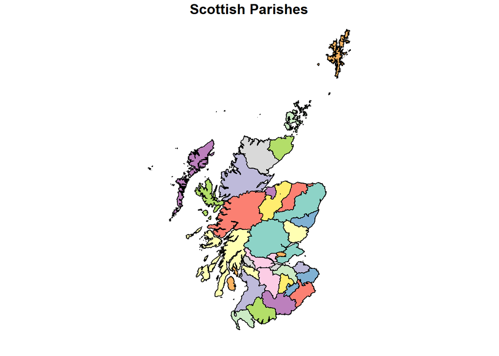

```r
plot(ParishesGeo, main = "Scottish Parishes")
```

As you can see from the plot, the dataset is made up of vector polygons. You can also change the basic presentation, such as the colour of the fill, line width and colour.

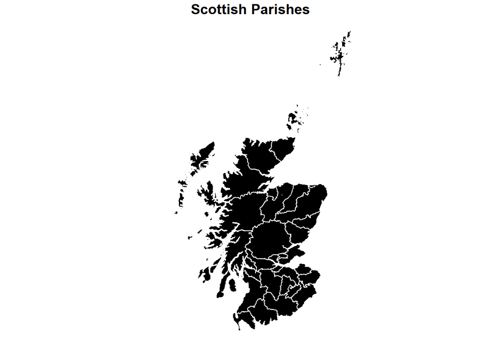

```r
plot(ParishesGeo,
     col = "black",
     lwd = 1,
     border = "white",
     main = "Scottish Parishes")
```

## Work on Illness Mentions

### Extract Information from the textual data

Because we want to see how often mention of a certain topic are present in the text we want to search for specific keywords

The first topic we are going to look at is Illness. So we are creating a new variable that would contain yes if the text contains one of the keywords or no if it does not

1.Search keywords

```r
Parish$Ilness<- ifelse(grepl("ill|ilness|sick|cholera|smallpox|plague|cough|typhoid|fever|measles|dysentery", Parish$text,
                             ignore.case = T), "yes","no")

head(Parish$Ilness)
```

```
## [1] "yes" "yes" "yes" "yes" "no"  "yes"
```

2. Group by Illness and geographical area

To do this we use a pipe, if you have never seen a pipe before is basically a way to perform a series of action on a dataset in a certain order (you can think at it as bullet points of actions)

```r
IlnessGroup <- Parish %>%
  group_by(Area) %>%
  summarise(Total = n(),
            count = sum(Ilness == "yes")) %>%
  mutate(per = round(count/Total, 2))

head(IlnessGroup)
```

```
## # A tibble: 6 × 4
##   Area     Total count   per
##   <chr>    <int> <int> <dbl>
## 1 Aberdeen  2193  1790  0.82
## 2 Argyle    1336  1093  0.82
## 3 Ayrshire  1493  1312  0.88
## 4 Banff      820   697  0.85
## 5 Berwick    676   571  0.84
## 6 Bute       147   128  0.87
```

3.Merge the two datasets

```r
MergedGeo <-merge(ParishesGeo,IlnessGroup,
                  by.x="JOIN_NAME_",
                  by.y="Area",
                  all.x = TRUE) # nb this is left join cause I want to preserve all the records present in ParishGeo
```

4.Check data to have merged properly

```r
head(MergedGeo, max.level = 2)
```

```
## Simple feature collection with 6 features and 4 fields
## Geometry type: MULTIPOLYGON
## Dimension:     XY
## Bounding box:  xmin: 92508.41 ymin: 571189.1 xmax: 414043.2 ymax: 868786.8
## Projected CRS: OSGB36 / British National Grid
##   JOIN_NAME_ Total count  per                       geometry
## 1   Aberdeen  2193  1790 0.82 MULTIPOLYGON (((394004.6 80...
## 2     Argyle  1336  1093 0.82 MULTIPOLYGON (((183373.2 73...
## 3   Ayrshire  1493  1312 0.88 MULTIPOLYGON (((218097.2 65...
## 4      Banff   820   697 0.85 MULTIPOLYGON (((316487.5 83...
## 5    Berwick   676   571 0.84 MULTIPOLYGON (((372205.7 66...
## 6       Bute   147   128 0.87 MULTIPOLYGON (((206008.4 63...
```

### Visualise the new dataset

1.Create a continuous color palette

```r
color.palette <- colorRampPalette(c("white", "red"))
```

2. Spatial plot using tmap

tm_shape is a function in the tmap package (Thematic maps). Thematic maps can be generated with great flexibility. The syntax for creating plots is similar to that of ggplot2, but tailored to maps. To plot a tmap, you will need to specify firstly tm_shape, layers then can be added with the + operator. tm_fill specifies the presentation of the polygons. To differentiate NA values from other valid entries, colorNA is added.

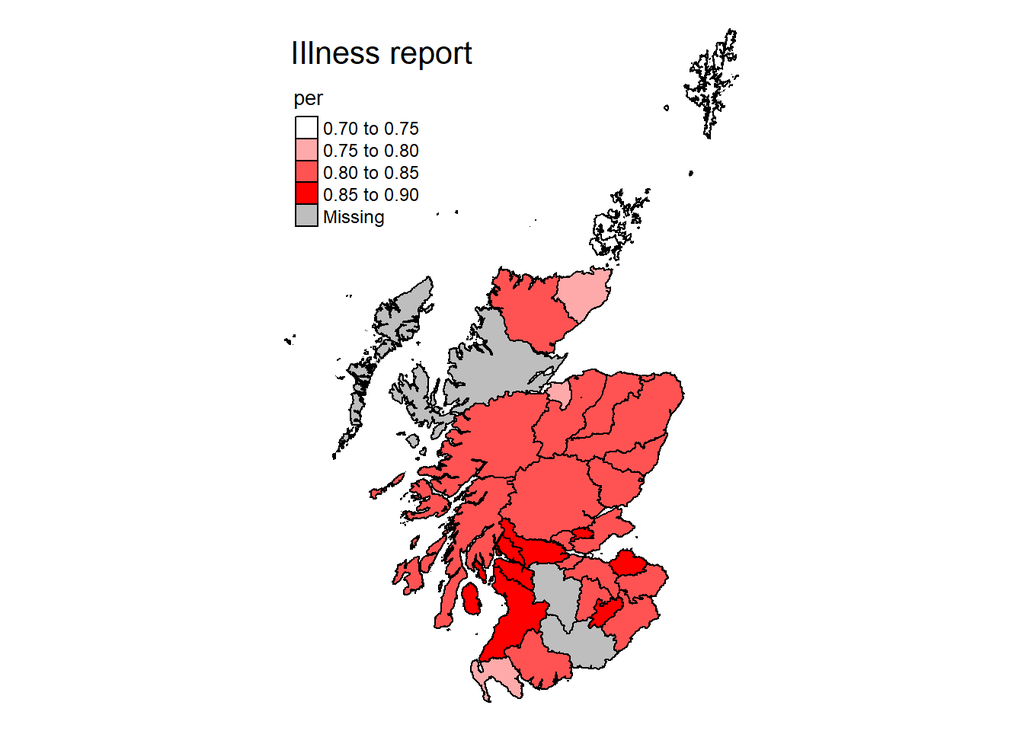

```r
tm_shape(MergedGeo) + # Specify the spatial object (MergedGeo) to be used in the map
  tm_fill("per", palette = color.palette(100), colorNA = "grey") + # Fill polygons based on 'per' variable, using a custom color palette with 100 colors; grey for NA values
  tm_borders(col = "black") + # Add black borders to each polygon
  tm_layout(title = "Illness report", legend.text.size = 0.75, legend.title.size = 1, frame = FALSE) # Set layout: add a title, resize legend text and title, remove frame
```